# Notebook 2

your name

June 28, 2022

# Fundamentals of Hydrology: Precipitation

Today, we are going to explore precipitation data. These data span several decades and are part of a Long Term Ecological Research Forest in Oregon. The [H.J.Andrews LTER](https://andrewsforest.oregonstate.edu/) is located in the Oregon Cascades. But before looking at these data, we need to load some packages that we installed in the previous session

```r
library(ggplot2)
library(dplyr)
library(lubridate)
```

We will also use a function created in R to assign the corresponding season to every date in our data set using the year 2012 as a reference (e.g.,[here](https://stackoverflow.com/questions/9500114/find-which-season-a-particular-date-belongs-to))

```r
#Season function
getSeason <- function(DATES){
  WS <- as.Date("2012-12-15", format = "%Y-%m-%d")#Winter solstice
  SE <- as.Date("2012-3-15",  format = "%Y-%m-%d")#Spring equinox
  SS <- as.Date("2012-6-15",  format = "%Y-%m-%d")#Summer solstice
  FE <- as.Date("2012-9-15",  format = "%Y-%m-%d")#Fall Equinox

  #Convert dates from any year to 2012 dates
  d <- as.Date(strftime(DATES, format = "2012-%m-%d"))

  ifelse(d >= WS | d < SE, "Winter",
         ifelse (d >= SE & d < SS, "Spring",
                 ifelse (d >= SS & d < FE, "Summer", "Fall")))
}
#One note: 2012 is a good year to which to convert all of the dates; since it is a leap year, any February 29ths in your data set will be handled smoothly.
```

We will also need an overall theme for our graphics (feel free to change the name of the theme-but be consistent across the code):

```r
#Defining a common theme for our graphics
theme_fg = theme(axis.text=element_text(colour="black",size=14),
                 axis.title.y = element_text(size = 20),
                 axis.title.x = element_text(size = 20),
                 panel.grid.minor= element_line(colour = "gray", linetype = "dotted"),
                 panel.grid.major = element_line(colour = "gray", linetype = "dashed"),
                 panel.border = element_rect(fill=NA, colour = "black", size=1),
                 panel.background=element_blank(),
                 axis.ticks.length = unit(0.254, "cm"),
                 axis.ticks = element_line(colour = "black", size=1),
                 axis.line = element_line(colour = "black"),
                 legend.position = c(.90,.90),
                 legend.direction = "vertical",
                 legend.background = element_rect(fill=alpha(0.1)),
                 legend.title = element_blank())
```

Let’s now load and prepare the data set:

```r
#Processing dataset
hjp_0 <- read.csv("220627_hja_precipt.csv")
hjp_1 <- dplyr::select(hjp_0,c("SITECODE","HEIGHT", "DATE", "PRECIP_TOT_DAY"))
hjp <- dplyr::filter(hjp_1, HEIGHT != "455")
hjp$DATE <- as.Date(hjp$DATE, origin = "1899-12-30", format = "%Y-%m-%d")
hjp$SEASON <- getSeason(hjp$DATE)
colnames(hjp) <- c("site", "elev","date","p_mm_day","ssn")
```

Let’s now explore the time series of total daily precipitation across multiple watersheds located at different elevations:

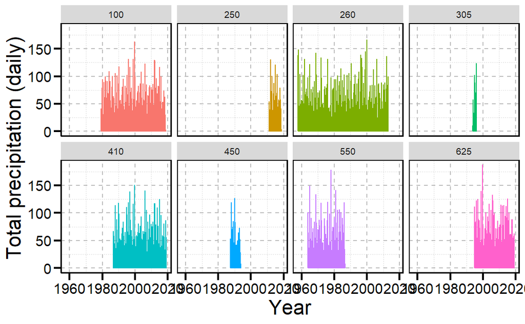

```r
p_select_plot <- ggplot(hjp, aes(date, p_mm_day, color = as.factor(elev), fill = as.factor(elev)))+
  geom_line()+
  ylab("Total precipitation (daily)")+
  xlab("Year")+
  theme_fg+
  theme(legend.position = "none")+
  facet_wrap(~as.factor(elev), ncol = 4)
p_select_plot
```

## **Question**: Which locations (elevations) would be more reliable to estimate long-term trends in precipitation? Why?

One of the challenging aspects of precipitation data is the abundance of zeros and the wide range of variability observed across the record. To better visualize these data, we could use a logarithmic scale. However, we will get errors for zero values, as the log (0) is not defined. So, we will use logarithms, but with a little math trick:

```r
hjp$log.p_mm_day <- log10(hjp$p_mm_day+1)
```

Let’s observe density plots of log-transformed precipt. data

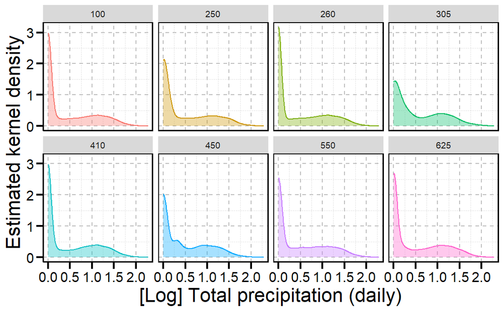

```r
p_select_plot2 <- ggplot(hjp, aes(x = log.p_mm_day, color = as.factor(elev), fill = as.factor(elev)))+
  geom_density(alpha = 0.35)+
  xlab("[Log] Total precipitation (daily)")+
  ylab("Estimated kernel density")+
  theme_fg+
  theme(legend.position = "none")+
  facet_wrap(~as.factor(elev), ncol = 4)
p_select_plot2
```

## **Question**: What kind of probability distribution could be close to these empirical distribution? Are all the distributions exactly equal? Which ones look a bit different? Why do you think so?

Let’s observe the distribution of precipitation across the seasons over the years

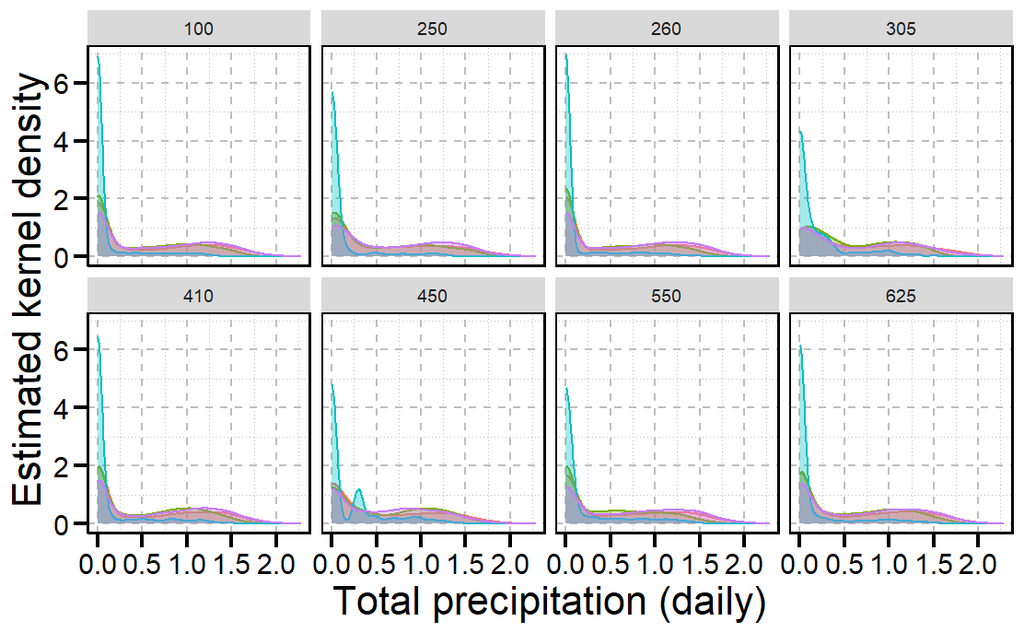

```r
p_select_plot3 <- ggplot(hjp, aes(x = log.p_mm_day, color = as.factor(ssn), fill = as.factor(ssn)))+
  geom_density(alpha = 0.35)+
  xlab("Total precipitation (daily)")+
  ylab("Estimated kernel density")+
  theme_fg+
  theme(legend.position = "none")+
  facet_wrap(~as.factor(elev), ncol = 4)
p_select_plot3
```

## **Question**: What kind of probability distribution could be close to these empirical distributions per season? Are all the distributions exactly equal? Which ones look a bit different? Why do you think so?

Let’s now take a look at the distribution of precipitation only during rainy days. To do so, let’s remove all values = 0.

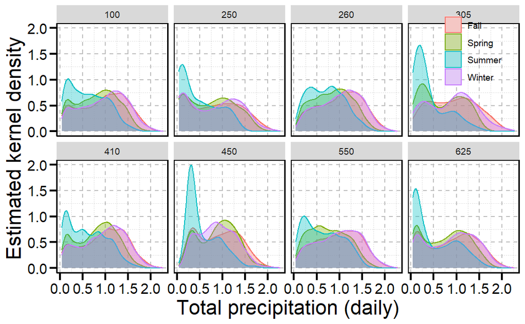

```r
p_select_plot4 <- ggplot(dplyr::filter(hjp,log.p_mm_day > 0),
                         aes(x = log.p_mm_day, color = as.factor(ssn), fill = as.factor(ssn)))+
  geom_density(alpha = 0.35)+# perhaps you need to use a kernel density method to account for differences in record length.
  xlab("Total precipitation (daily)")+
  ylab("Estimated kernel density")+
  theme_fg+
  facet_wrap(~as.factor(elev), ncol = 4)
p_select_plot4
```